# R for physical scientists 1: Introduction to R

Matt Lacey and Taha Ahmed

# What is R?

> R is an integrated suite of software facilities for data manipulation, calculation and graphical display.
- Developed at University of Auckland, NZ from 1992 - version 1.0 released in 2000
- Developed by statisticians for statisticians, now widely used in other areas, e.g. data mining
- Interpreted language - no compiling of code
- A true programming language - much of R is written in R, and functionality is extended through add-on packages (>9000 currently exist at the Comprehensive R Archive Network, CRAN)

# Advantages

- Free and open source
- Cross-platform
- RStudio (also free!)
- Excellent package system and community support
- Plays well with other software - both importing and exporting
- Excellent capabilities for reproducible research

# Disadvantages

- Syntax can seem strange to those already familiar with other languages, learning curve might be steep
- Official documentation is often difficult to understand
- Error messages sometimes vague and/or unhelpful
- Speed and memory management is a weakness - but only an issue if working with large datasets, and is largely tackled by various add-on packages!

# Demonstration

R can make complex data analysis very fast.

With R, we can take a complex raw file (the full set has 104,875 lines)…

```
## id, timestamp, demand, frequency, coal, nuclear, ccgt, wind, french_ict, dutch_ict, irish_ict, ew_ict, pumped, hydro, oil, ocgt, other
## 377525, 2015-01-01 00:00:04, 28809, 50.09, 9079, 8049, 3360, 5251, 582, 900, -72, -136, 15, 443, 0, 0, 1157
## 377526, 2015-01-01 00:05:02, 28645, 50.091999, 8947, 8053, 3369, 5254, 586, 898, -100, -134, 0, 441, 0, 0, 1157
## 377527, 2015-01-01 00:10:02, 28768, 50.116001, 8843, 8052, 3372, 5272, 586, 898, -100, -134, 0, 440, 0, 0, 1157
## 377528, 2015-01-01 00:15:02, 28917, 50.044998, 8763, 8047, 3339, 5303, 586, 898, -100, -134, 0, 439, 0, 0, 1155
## 377529, 2015-01-01 00:20:02, 28964, 50.029999, 8818, 8051, 3386, 5223, 586, 898, -100, -134, 0, 440, 0, 0, 1155
## 377530, 2015-01-01 00:25:02, 29055, 50.006001, 8906, 8055, 3392, 5189, 586, 898, -100, -134, 0, 441, 0, 0, 1155
## 377531, 2015-01-01 00:30:03, 29062, 50.016998, 8941, 8048, 3398, 5138, 586, 898, -100, -134, 0, 442, 0, 0, 1155
## 377532, 2015-01-01 00:35:01, 29041, 49.914001, 8972, 8046, 3408, 5086, 1006, 854, -26, -120, 0, 438, 0, 0, 1156
## 377533, 2015-01-01 00:40:02, 29394, 49.924, 9320, 8048, 3472, 5025, 1006, 854, -26, -120, 0, 435, 0, 0, 1156
```

Import it with one line of code:

```r
gridwatch <- read.csv("http://lacey.se/dl/gridwatch-2015.csv", header = TRUE)
```

Process it and analyse it in a few more lines…

```r
df <- gridwatch %>%
  mutate(timestamp = ymd_hms(.$timestamp),
         month = month(.$timestamp, label = TRUE)) %>%
  gather(source, power, -timestamp, -demand, -frequency, -id, -month) %>%
  group_by(source, month) %>%
  summarise(mean_power = mean(power))
```

And make a plot in just a few more:

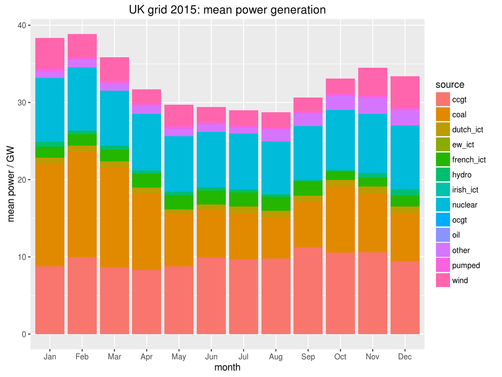

```r
ggplot(df, aes(x = month, y = mean_power/1000)) +
  geom_bar(aes(fill = source), stat = "identity") +
  ylab("mean power / GW") +
  ggtitle("UK grid 2015: mean power generation")
```

# About this course

# What is the aim?

- To give you an accessible, practical introduction to the R language and environment
- To give a modern, up-to-date introduction to how to approach data analysis and visualisation with R’s most useful add-on packages
- To be challenging, relevant, and encourage good practice from the start
- To give you enough of a grounding so that you can confidently start to use R for your own purposes, and to continue learning on your own

# Get started

During this course you can follow the examples here with RStudio via our private server: rfps.chepec.se

Get R for yourself at r-project.org and RStudio Desktop at rstudio.com

# RStudio

[figure not shown]

# RStudio shortcuts

- **Tab** - Generic autocomplete - will suggest function or file names.
- **Ctrl/Cmd + Up arrow** - Similar to above - but will suggest commands *you’ve typed before* (only works in console)
- **Ctrl/Cmd + Enter** - executes selected code in the editor

# Console

# Interpreter

R is an interpreted language. One of the console’s most basic functions is as a calculator.

```r
2 + 2
```

```
## [1] 4
```

```r
4 * 9
```

```
## [1] 36
```

```r
(10^3.2 + 7) / 17
```

```
## [1] 93.64078
```

# Multi-line calculations

If you don’t close a set of brackets or leave an operator without a right-hand-side argument, the console will show a new line starting with `+`.

R will only run the command when the expression is complete.

# Objects and data types

Assign values to variables with `<-`

```r
a <- 5
```

`a` now appears in the workspace window.

If you type the name of the variable, R will tell you what it is:

```r
a
```

```
## [1] 5
```

`class()` tells you what sort of variable it is

```r
class(a)
```

```
## [1] "numeric"
```

Can do calculations on `numeric` variables:

```r
a + 7
```

```
## [1] 12
```

Variables can be character strings:

```r
b <- "hello"
class(b)
```

```
## [1] "character"
```

or logical values:

```r
c <- TRUE
class(c)
```

```
## [1] "logical"
```

and many other things we’ll find out about later…

You can’t do calculations on character strings…

```r
b
```

```
## [1] "hello"
```

```r
b * 3
```

```
## Error in b * 3: non-numeric argument to binary operator
```

# Vectors

A `vector` is a 1-dimensional array of values. Attach values together with `c()` (concatenate):

```r
d <- c(3, 4, 5)
d
```

```
## [1] 3 4 5
```

Functions such as maths operators will operate on every element in the vector individually:

```r
d * 3
```

```
## [1]  9 12 15
```

All elements in a vector must be of the same type. R will coerce them to the same type if they aren’t:

```r
e <- c(3, "hello", TRUE)
str(e)
```

```
##  chr [1:3] "3" "hello" "TRUE"
```

Note: the `str()` function is useful for checking what information is stored in a variable.

# Indexing

Access specific elements in a vector with `[]`

```r
f <- c(2, 4, 7, 10, 23, 33, 49, 80)
f[1]
```

```
## [1] 2
```

Use `:` to specify a range

```r
f[3:6]
```

```
## [1]  7 10 23 33
```

`:` generates a sequence in steps of 1 or -1. Can be combined with `c()` to pick out whatever values you wish:

```r
c(1:3, 7)
```

```
## [1] 1 2 3 7
```

```r
f[c(1:3, 7)]
```

```
## [1]  2  4  7 49
```

Maybe you want to assign a range to a variable:

```r
range <- c(1:3, 7)
f[range]
```

```
## [1]  2  4  7 49
```

# Editing values

Edit elements in place:

```r
f
```

```
## [1]  2  4  7 10 23 33 49 80
```

```r
f[1] <- 15
f
```

```
## [1] 15  4  7 10 23 33 49 80
```

# Finding values

`which()` returns the index/indices of an object matching a certain value or range.

```r
which(f == 15)
```

```
## [1] 1
```

```r
which(f < 20)
```

```
## [1] 1 2 3 4
```

```r
f[which(f < 20)]
```

```
## [1] 15  4  7 10
```

# Matrices

A `matrix` is a two-dimensional array:

```r
g <- matrix(c(1:6), nrow = 2)
g
```

```
##      [,1] [,2] [,3]
## [1,]    1    3    5
## [2,]    2    4    6
```

```r
class(g)
```

```
## [1] "matrix"
```

Index matrices with `[row, column]`:

```r
g[2, 2]
```

```
## [1] 4
```

```r
g[1:2, 2:3]
```

```
##      [,1] [,2]
## [1,]    3    5
## [2,]    4    6
```

Select entire rows:

```r
g[1, ]
```

```
## [1] 1 3 5
```

```r
g[, 3]
```

```
## [1] 5 6
```

For most purposes, 2D data is most conveniently handled with `data.frame`s, which we will deal with later…

Multi-dimensional arrays are possible with `array()`, but we won’t go into that!

# Lists

A `list()` is a collection of other data structures. List elements don’t have to be the same length, or the same type!

```r
h <- list(c(1:5), "hello", TRUE)
str(h)
```

```
## List of 3
##  $ : int [1:5] 1 2 3 4 5
##  $ : chr "hello"
##  $ : logi TRUE
```

A `list` element can be anything, even another `list`…

# Indexing lists

`lists` are indexed with `[]` or `[[]]`.

```r
h
```

```
## [[1]]
## [1] 1 2 3 4 5
##
## [[2]]
## [1] "hello"
##
## [[3]]
## [1] TRUE
```

Using `[]` returns a `list` of the selected `list` elements:

```r
str(h[1])
```

```
## List of 1
##  $ : int [1:5] 1 2 3 4 5
```

whereas `[[]]` returns the element itself:

```r
str(h[[1]])
```

```
##  int [1:5] 1 2 3 4 5
```

```r
h[[1]][3]
```

```
## [1] 3
```

You can’t do calculations on lists directly, just on their elements:

```r
h * 3
```

```
## Error in h * 3: non-numeric argument to binary operator
```

```r
h[1] * 3
```

```
## Error in h[1] * 3: non-numeric argument to binary operator
```

```r
h[[1]] * 3
```

```
## [1]  3  6  9 12 15
```

`list` elements can have names:

```r
j <- list(
  a = c(1:5), # Note the = sign!!
  b = "hello",
  c = TRUE
)
str(j)
```

```
## List of 3
##  $ a: int [1:5] 1 2 3 4 5
##  $ b: chr "hello"
##  $ c: logi TRUE
```

And the elements can be addressed with `$`:

```r
j$a
```

```
## [1] 1 2 3 4 5
```

# Removing variables

Get a list of all variables in the current workspace with `ls()`

```r
ls()
```

```
##  [1] "a"     "b"     "c"     "d"     "e"     "f"     "g"     "h"
##  [9] "j"     "range"
```

Remove all variables with `rm()`:

```r
rm(list = ls())
```

Remove a single variable (e.g. `a`) with:

```r
rm(a)
```

# Exercise

Almost anything in R can be assigned to a variable. Try assigning some variables, and doing calculations on them. Here are some self-explanatory maths functions to try:

- `log()`, `log10()`, `log2()`, `exp()`, `sqrt()`, `cos()`, `sin()`, `tan()`, `acos()`, `asin()`, `atan()`

Maybe try out `seq()` for making sequences, e.g.

```r
seq(from = 1, to = 30, by = 3)
```

```
##  [1]  1  4  7 10 13 16 19 22 25 28
```

# Functions

We’ve already seen a few: `class()`, `str()`, etc.

A function does a particular job with the *arguments* it is given.

For example, `rnorm()` generates random numbers with a normal distribution. `args(fun)` is a function which returns the arguments of a function with the name `fun`

```r
args(rnorm)
```

```
## function (n, mean = 0, sd = 1)
## NULL
```

Arguments with specified values are defaults.

```r
a <- rnorm(100)
head(a, 5) # head(a, n) returns the first n values of a
```

```
## [1]  0.1465753 -0.6190084  2.3473131 -0.5795668  0.2074588
```

```r
mean(a) # requires only one argument, but takes options
```

```
## [1] 0.08831999
```

Functions can be nested:

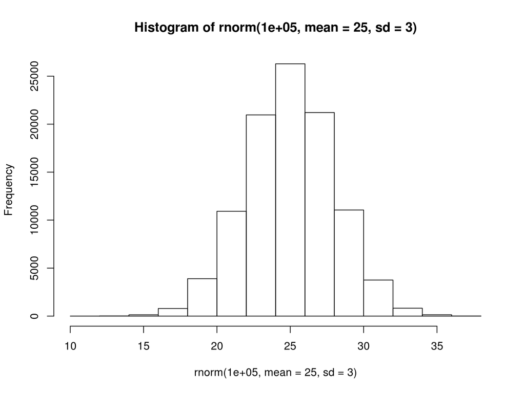

```r
# plot a histogram for 100,000 random numbers mean 25 and s.d. 3
hist(rnorm(1E5, mean = 25, sd = 3))
```

R has many built in functions, especially for statistical purposes:

```r
summary(a)
```

```
##     Min.  1st Qu.   Median     Mean  3rd Qu.     Max.
## -1.91200 -0.63040 -0.03467  0.08832  0.73680  3.07900
```

# Help

Use `?` to see documentation for any given function.

```r
?rnorm
```

# `example()`

Use `example()` to run the examples of the function described in the documentation:

```r
example(mean)
```

```
##
## mean> x <- c(0:10, 50)
##
## mean> xm <- mean(x)
##
## mean> c(xm, mean(x, trim = 0.10))
## [1] 8.75 5.50
```

# Installing packages

# What are packages?

Packages are written by other users which add new functionality to R.

They can be simply functions of other R functions, modified or combined to do some particular job, such as a particular analysis…

…or they can add new capability entirely - providing functions written in another language which manipulate objects in R.

Add-on packages are most conveniently installed from a CRAN mirror with `install.packages("packagename")`

```r
install.packages("readxl")
```

tip: you can check if a package is already installed with:

```r
"readxl" %in% installed.packages()
```

```
## [1] TRUE
```

# Loading packages

To load a package so you can use the functions the package provides, use `library()`:

```r
library(readxl)
```

# Exercise!

Check that the package `ggplot2` is installed in the system. If it’s not, install it.

# Solution

```r
"ggplot2" %in% installed.packages()
```

```
## [1] TRUE
```

if `FALSE`…

```r
install.packages("ggplot2")
```

We’ll come back to using this package in a bit!

# Importing and checking data

# `read.table`

“Base” R contains a function for reading in data from standard text files, `read.table`. But it has quite a lot of arguments:

```r
args(read.table)
```

```
## function (file, header = FALSE, sep = "", quote = "\"'", dec = ".",
##     numerals = c("allow.loss", "warn.loss", "no.loss"), row.names,
##     col.names, as.is = !stringsAsFactors, na.strings = "NA",
##     colClasses = NA, nrows = -1, skip = 0, check.names = TRUE,
##     fill = !blank.lines.skip, strip.white = FALSE, blank.lines.skip = TRUE,
##     comment.char = "#", allowEscapes = FALSE, flush = FALSE,
##     stringsAsFactors = default.stringsAsFactors(), fileEncoding = "",
##     encoding = "unknown", text, skipNul = FALSE)
## NULL
```

# `read.csv` and `read.delim`

Simplified functions are available:

- `read.csv()` for *comma separated value* files (.csv)
- `read.delim()` for *tab delimited* files

Alternative functions exist for the continental European convention, i.e., `1,11;2,04;3,14`, namely `read.csv2()` and `read.delim2()`

If you look at the arguments for `read.csv()`, for example:

```r
args(read.csv)
```

```
## function (file, header = TRUE, sep = ",", quote = "\"", dec = ".",
##     fill = TRUE, comment.char = "", ...)
## NULL
```

You can see that

```r
read.csv2(x)
```

is equivalent to

```r
read.csv(x, sep = ";", dec = ",")
```

# Exercise!

There is a built-in dataset in R called `mtcars`.

```r
str(mtcars)
```

```
## 'data.frame':    32 obs. of  11 variables:
##  $ mpg : num  21 21 22.8 21.4 18.7 18.1 14.3 24.4 22.8 19.2 ...
##  $ cyl : num  6 6 4 6 8 6 8 4 4 6 ...
##  $ disp: num  160 160 108 258 360 ...
##  $ hp  : num  110 110 93 110 175 105 245 62 95 123 ...
##  $ drat: num  3.9 3.9 3.85 3.08 3.15 2.76 3.21 3.69 3.92 3.92 ...
##  $ wt  : num  2.62 2.88 2.32 3.21 3.44 ...
##  $ qsec: num  16.5 17 18.6 19.4 17 ...
##  $ vs  : num  0 0 1 1 0 1 0 1 1 1 ...
##  $ am  : num  1 1 1 0 0 0 0 0 0 0 ...
##  $ gear: num  4 4 4 3 3 3 3 4 4 4 ...
##  $ carb: num  4 4 1 1 2 1 4 2 2 4 ...
```

Look at the help file for `write.table()`.

Write two lines of code: one to export `mtcars` to a tab-delimited file called `mtcars.txt`; and one to reimport the `mtcars.txt` file to a new variable called `df`.

# Solution!

Your code should look something like this:

```r
write.table(mtcars, "mtcars.txt", sep = "\t")
df <- read.delim("mtcars.txt")
```

Tip: don’t call your data `data` - it’s already the name of a function!

# Exercise again!

Type these commands:

```r
library(readxl)
download.file("http://lacey.se/dl/rfps-datasets1.xlsx", "rfps-datasets1.xlsx", "curl")
```

Look in the help files for the functions `excel_sheets()` and `read_excel()` from the `readxl` package. Find out what spreadsheets are in the file you’ve downloaded, and import them!

# Solution

For example:

```r
excel_sheets("rfps-datasets1.xlsx")
```

```
## [1] "mtcars" "iris"
```

```r
sheet1 <- read_excel("rfps-datasets1.xlsx", 1)
sheet2 <- read_excel("rfps-datasets1.xlsx", "iris")
```

# Data frames

`read.table` and its related functions create a `data.frame`, which is essentially a list underneath but with some of the properties of matrices:

- all columns have to be the same length
- columns can be of different data types, but all elements in a column must be the same type
- you can index specific rows and columns with `[row, column]`
- you can index specific columns with `$`

# Looking into data frames

Let’s try some things with the data frame `mtcars` we’ve already looked at. We can look at the first 5 rows…

```r
head(mtcars, 5)
```

```
##                    mpg cyl disp  hp drat    wt  qsec vs am gear carb
## Mazda RX4         21.0   6  160 110 3.90 2.620 16.46  0  1    4    4
## Mazda RX4 Wag     21.0   6  160 110 3.90 2.875 17.02  0  1    4    4
## Datsun 710        22.8   4  108  93 3.85 2.320 18.61  1  1    4    1
## Hornet 4 Drive    21.4   6  258 110 3.08 3.215 19.44  1  0    3    1
## Hornet Sportabout 18.7   8  360 175 3.15 3.440 17.02  0  0    3    2
```

…or the last 5…

```r
tail(mtcars, 5)
```

```
##                 mpg cyl  disp  hp drat    wt qsec vs am gear carb
## Lotus Europa   30.4   4  95.1 113 3.77 1.513 16.9  1  1    5    2
## Ford Pantera L 15.8   8 351.0 264 4.22 3.170 14.5  0  1    5    4
## Ferrari Dino   19.7   6 145.0 175 3.62 2.770 15.5  0  1    5    6
## Maserati Bora  15.0   8 301.0 335 3.54 3.570 14.6  0  1    5    8
## Volvo 142E     21.4   4 121.0 109 4.11 2.780 18.6  1  1    4    2
```

What are the column names and row names?

```r
colnames(mtcars)
```

```
##  [1] "mpg"  "cyl"  "disp" "hp"   "drat" "wt"   "qsec" "vs"   "am"   "gear"
## [11] "carb"
```

```r
rownames(mtcars)
```

```
##  [1] "Mazda RX4"           "Mazda RX4 Wag"       "Datsun 710"
##  [4] "Hornet 4 Drive"      "Hornet Sportabout"   "Valiant"
##  [7] "Duster 360"          "Merc 240D"           "Merc 230"
## [10] "Merc 280"            "Merc 280C"           "Merc 450SE"
## [13] "Merc 450SL"          "Merc 450SLC"         "Cadillac Fleetwood"
## [16] "Lincoln Continental" "Chrysler Imperial"   "Fiat 128"
## [19] "Honda Civic"         "Toyota Corolla"      "Toyota Corona"
## [22] "Dodge Challenger"    "AMC Javelin"         "Camaro Z28"
## [25] "Pontiac Firebird"    "Fiat X1-9"           "Porsche 914-2"
## [28] "Lotus Europa"        "Ford Pantera L"      "Ferrari Dino"
## [31] "Maserati Bora"       "Volvo 142E"
```

Select rows and columns in the same way you would with matrices:

```r
mtcars[3, ]
```

```
##             mpg cyl disp hp drat   wt  qsec vs am gear carb
## Datsun 710 22.8   4  108 93 3.85 2.32 18.61  1  1    4    1
```

```r
mtcars[, 5]
```

```
##  [1] 3.90 3.90 3.85 3.08 3.15 2.76 3.21 3.69 3.92 3.92 3.92 3.07 3.07 3.07
## [15] 2.93 3.00 3.23 4.08 4.93 4.22 3.70 2.76 3.15 3.73 3.08 4.08 4.43 3.77
## [29] 4.22 3.62 3.54 4.11
```

Or by name!

```r
mtcars["Toyota Corolla", ]
```

```
##                 mpg cyl disp hp drat    wt qsec vs am gear carb
## Toyota Corolla 33.9   4 71.1 65 4.22 1.835 19.9  1  1    4    1
```

```r
mtcars[, "disp"]
```

```
##  [1] 160.0 160.0 108.0 258.0 360.0 225.0 360.0 146.7 140.8 167.6 167.6
## [12] 275.8 275.8 275.8 472.0 460.0 440.0  78.7  75.7  71.1 120.1 318.0
## [23] 304.0 350.0 400.0  79.0 120.3  95.1 351.0 145.0 301.0 121.0
```

More conveniently, you can address columns with `$`

```r
mtcars$disp
```

```
##  [1] 160.0 160.0 108.0 258.0 360.0 225.0 360.0 146.7 140.8 167.6 167.6
## [12] 275.8 275.8 275.8 472.0 460.0 440.0  78.7  75.7  71.1 120.1 318.0
## [23] 304.0 350.0 400.0  79.0 120.3  95.1 351.0 145.0 301.0 121.0
```

# Quick (and tough) test!

`identical(x, y)` checks to see if elements `x` and `y` are identical to each other. Why is:

```r
identical(mtcars[["disp"]], mtcars["disp"])
```

```
## [1] FALSE
```

but

```r
identical(mtcars[["disp"]], mtcars[, "disp"])
```

```
## [1] TRUE
```

?

# Answer…

`data.frame`s are basically `list`s

```r
str(mtcars[["disp"]])
```

```
##  num [1:32] 160 160 108 258 360 ...
```

```r
str(mtcars["disp"])
```

```
## 'data.frame':    32 obs. of  1 variable:
##  $ disp: num  160 160 108 258 360 ...
```

But share properties of matrices.

```r
str(mtcars[, "disp"])
```

```
##  num [1:32] 160 160 108 258 360 ...
```

The `,` matters!

Make new data frames in the same way you would with a list:

```r
df2 <- data.frame(
  a = rnorm(50),
  b = rnorm(50),
  c = rnorm(50)
)

str(df2)
```

```
## 'data.frame':    50 obs. of  3 variables:
##  $ a: num  -1.7779 0.0081 0.4674 0.6731 -0.0866 ...
##  $ b: num  0.897 -1.154 2.084 -0.033 -0.177 ...
##  $ c: num  2.00094 -0.31042 -0.59865 -0.35289 0.00305 ...
```

You can add new columns, as long as they are vectors of the same length as the data frame - for example, if I want to convert US mpg into l/100 km:

```r
mtcars2 <- mtcars
mtcars2$lp100km <- 235.2 / mtcars2$mpg
head(mtcars2)
```

```
##                    mpg cyl disp  hp drat    wt  qsec vs am gear carb
## Mazda RX4         21.0   6  160 110 3.90 2.620 16.46  0  1    4    4
## Mazda RX4 Wag     21.0   6  160 110 3.90 2.875 17.02  0  1    4    4
## Datsun 710        22.8   4  108  93 3.85 2.320 18.61  1  1    4    1
## Hornet 4 Drive    21.4   6  258 110 3.08 3.215 19.44  1  0    3    1
## Hornet Sportabout 18.7   8  360 175 3.15 3.440 17.02  0  0    3    2
## Valiant           18.1   6  225 105 2.76 3.460 20.22  1  0    3    1
##                    lp100km
## Mazda RX4         11.20000
## Mazda RX4 Wag     11.20000
## Datsun 710        10.31579
## Hornet 4 Drive    10.99065
## Hornet Sportabout 12.57754
## Valiant           12.99448
```

`cbind()` can be used to bind data.frames or vectors together by column; `rbind()` can bind data.frames, vectors or lists by row:

```r
nrow(mtcars2)
```

```
## [1] 32
```

```r
r_num <- rnorm(nrow(mtcars2))
mtcars3 <- cbind(mtcars2, r_num)
head(mtcars3)
```

```
##                    mpg cyl disp  hp drat    wt  qsec vs am gear carb
## Mazda RX4         21.0   6  160 110 3.90 2.620 16.46  0  1    4    4
## Mazda RX4 Wag     21.0   6  160 110 3.90 2.875 17.02  0  1    4    4
## Datsun 710        22.8   4  108  93 3.85 2.320 18.61  1  1    4    1
## Hornet 4 Drive    21.4   6  258 110 3.08 3.215 19.44  1  0    3    1
## Hornet Sportabout 18.7   8  360 175 3.15 3.440 17.02  0  0    3    2
## Valiant           18.1   6  225 105 2.76 3.460 20.22  1  0    3    1
##                    lp100km      r_num
## Mazda RX4         11.20000  0.3686009
## Mazda RX4 Wag     11.20000 -0.4260769
## Datsun 710        10.31579  0.7911235
## Hornet 4 Drive    10.99065 -0.3256832
## Hornet Sportabout 12.57754  0.5359346
## Valiant           12.99448 -1.2003570
```

Just make sure all the columns are the same length!

# Let’s make a plot!

# `ggplot2`

> `ggplot2` is a plotting system for R, based on the grammar of graphics, which tries to take the good parts of `base` and `lattice` graphics and none of the bad parts. It takes care of many of the fiddly details that make plotting a hassle (like drawing legends) as well as providing a powerful model of graphics that makes it easy to produce complex multi-layered graphics.

```r
library(ggplot2)
```

`ggplot2` contains a basic function `qplot()`, which can most simply be used with the form `qplot(x, y, data)`:

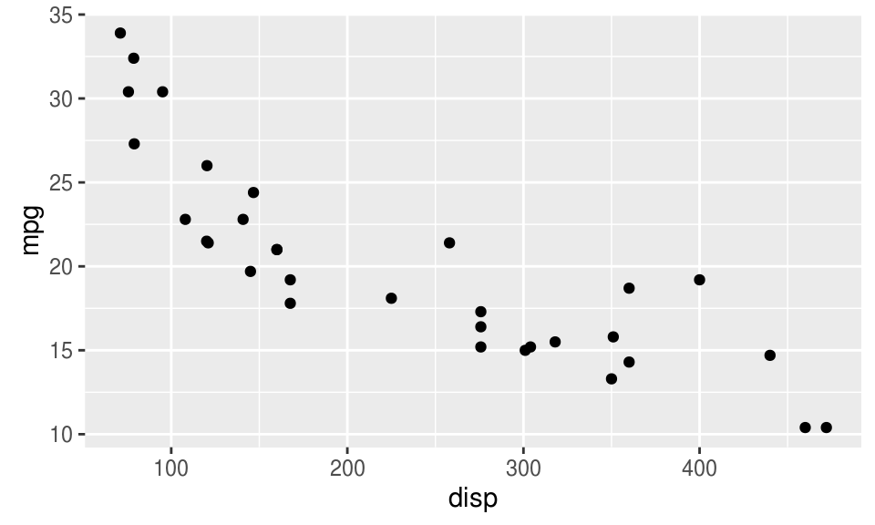

```r
qplot(disp, mpg, data = mtcars)
```

`qplot()` is a convenient “wrapper” for the main function , `ggplot()`. The same plot can be generated with:

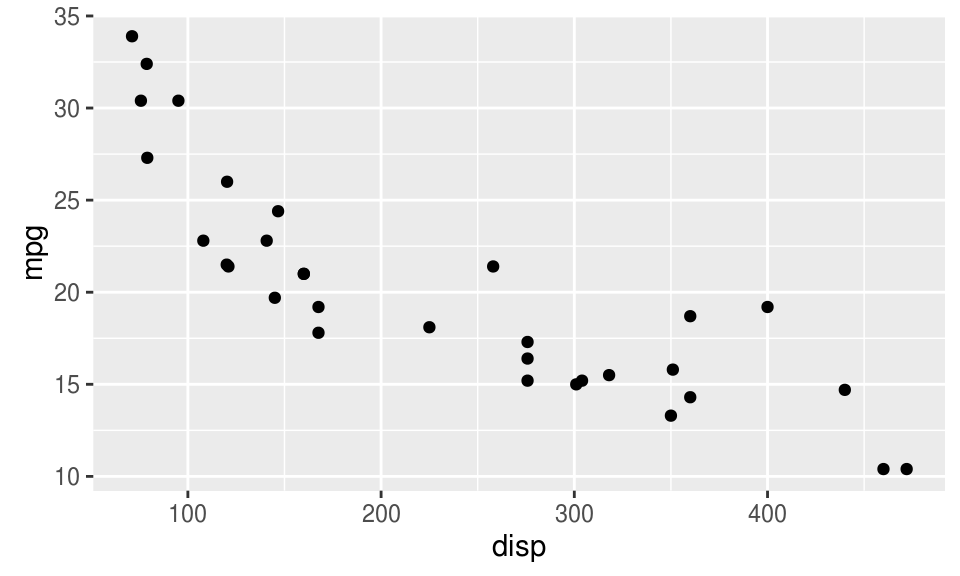

```r
ggplot(mtcars, aes(x = disp, y = mpg)) +
  geom_point()
```

```r
args(ggplot)
```

```
## function (data = NULL, mapping = aes(), ..., environment = parent.frame())
## NULL
```

`aes()` specifies “aesthetics” (e.g., `x` and `y` values, data point colour, size, etc) to be mapped to variables. By default, specified variables are taken as columns in `data`.

Aesthetics which are specified in the top `ggplot()` function are passed down to all additional arguments.

Link together arguments with `+`:

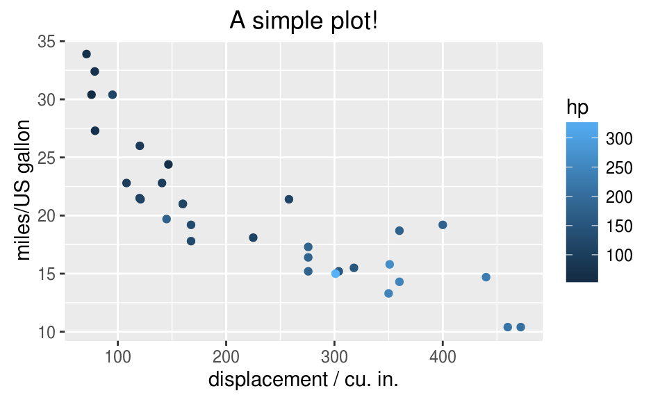

```r
ggplot(mtcars, aes(x = disp, y = mpg)) +
  geom_point(aes(color = hp)) +
  xlab("displacement / cu. in.") +
  ylab("miles/US gallon") +
  ggtitle("A simple plot!")
```

# Try it out!

Look in the datasets `mtcars` and `iris` (the latter you haven’t seen yet). Try out `qplot()` and `ggplot()` with these datasets however you like and see what happens.

# That’s all for today!

Useful functions:

- `class()`, `str()`
- `<-`, `c()`, `list()`, `data.frame()`, `rm()`
- `[`, `[[`, `$`, `which()`, `summary()`
- `args()`, `?`, `example()`
- `install.packages()`, `library()`
- `read.table()`, `read.csv()`, `read.delim()`, `write.table()`
- `head()`, `tail()`, `colnames()`, `rownames()`
- `qplot()`, `ggplot()`

(and get R at r-project.org and RStudio at rstudio.com)